# Multiple Linear Regression

Rhenium Yuan

2023-04-10

# Mutliple Linear Regression

Multiple linear regression (MLR), also known simply as multiple regression, is a statistical technique that uses several explanatory variables to predict the outcome of a response variable.

$$\hat{y}=b_0+b_1x_1+b_2x_2+\dots+b_nx_n$$

```r
fit = lm(heart.disease ~ biking + smoking, data = heart)
summary(fit)
```

```
##
## Call:
## lm(formula = heart.disease ~ biking + smoking, data = heart)
##
## Residuals:
##     Min      1Q  Median      3Q     Max
## -2.1789 -0.4463  0.0362  0.4422  1.9331
##
## Coefficients:
##              Estimate Std. Error t value Pr(>|t|)
## (Intercept) 14.984658   0.080137  186.99   <2e-16 ***
## biking      -0.200133   0.001366 -146.53   <2e-16 ***
## smoking      0.178334   0.003539   50.39   <2e-16 ***
## ---
## Signif. codes:  0 '***' 0.001 '**' 0.01 '*' 0.05 '.' 0.1 ' ' 1
##
## Residual standard error: 0.654 on 495 degrees of freedom
## Multiple R-squared:  0.9796, Adjusted R-squared:  0.9795
## F-statistic: 1.19e+04 on 2 and 495 DF,  p-value: < 2.2e-16
```

## Assumptions

- **Random sampling**: This is an usual assumption of a lot of tests. Note that the wider the population you can represent, the more you can generalize your results.
- **Multivariate normality**: no multivariate outliers (combo of values on 2 or more variables that are extremely rare).
- **Random sampling**: This is an usual assumption of a lot of tests. Note that the wider the population you can represent, the more you can generalize your results.

## Standard regression equation

**Beta weights**

```r
fitz = lm(scale(heart.disease) ~ scale(biking) + scale(smoking), data = heart)
summary(fitz)
```

```
##
## Call:
## lm(formula = scale(heart.disease) ~ scale(biking) + scale(smoking),
##     data = heart)
##
## Residuals:
##      Min       1Q   Median       3Q      Max
## -0.47658 -0.09762  0.00792  0.09671  0.42283
##
## Coefficients:
##                  Estimate Std. Error t value Pr(>|t|)
## (Intercept)    -6.119e-17  6.410e-03    0.00        1
## scale(biking)  -9.403e-01  6.418e-03 -146.53   <2e-16 ***
## scale(smoking)  3.234e-01  6.418e-03   50.39   <2e-16 ***
## ---
## Signif. codes:  0 '***' 0.001 '**' 0.01 '*' 0.05 '.' 0.1 ' ' 1
##
## Residual standard error: 0.1431 on 495 degrees of freedom
## Multiple R-squared:  0.9796, Adjusted R-squared:  0.9795
## F-statistic: 1.19e+04 on 2 and 495 DF,  p-value: < 2.2e-16
```

# Correlation and Coefficient of Determination

$$R^2=\beta_1r_{1y}+\beta_2r_{2y}=\frac{r_{1y}^2+r_{2y}^2-2r_{1y}r_{2y}r_{12}}{1-r_{12}^2}$$
F test for R
$$F(P,N-P-1)=\frac{R^2/P}{(1-R^2)/(N-P-1)}$$
## Ajusted $R^2$

$$R_{adj}^2=R^2-\frac{P(1-R^2)}{N-P-1}=R^2(1-\frac{1}{F})$$

## Partial Correlation

The beta weight of a predictor is the multiple of SDs that the criterion (y) changes when that predictor (x) is increased by 1 SD, given that all other variables are held constant.

When your focus is on the relation between 2 particular variables (one is y, one is x in our case). However, for multiple correlation, there might be a number of variables (other x) that affect them both.

The pr between two variables is their correlation after holding a 3rd variable constant.

$$pr_1=\frac{r_{1y}-r_{2y}r_{12}}{\sqrt{(1-r_{2y}^2)(1-r_{12}^2)}}$$

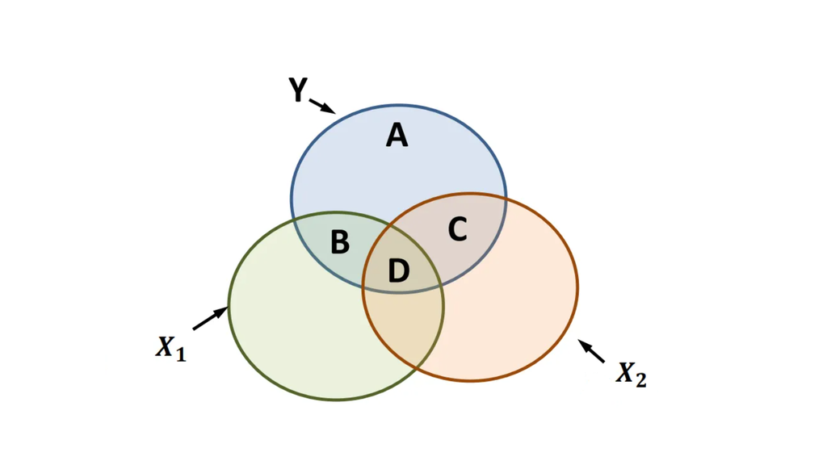

Venn

### t test for pr

$$t(N-V-2)=\frac{pr\sqrt{N-V-2}}{\sqrt{1-pr^2}}$$
*V refers to the number of variables taken out*

```r
ppcor::pcor(heart[,-1])
```

```
## $estimate
##                   biking   smoking heart.disease
## biking         1.0000000 0.9053403    -0.9886677
## smoking        0.9053403 1.0000000     0.9147891
## heart.disease -0.9886677 0.9147891     1.0000000
##
## $p.value
##                      biking       smoking heart.disease
## biking         0.000000e+00 3.100667e-186  0.000000e+00
## smoking       3.100667e-186  0.000000e+00 5.192235e-197
## heart.disease  0.000000e+00 5.192235e-197  0.000000e+00
##
## $statistic
##                   biking  smoking heart.disease
## biking           0.00000 47.42919    -146.52547
## smoking         47.42919  0.00000      50.38667
## heart.disease -146.52547 50.38667       0.00000
##
## $n
## [1] 498
##
## $gp
## [1] 1
##
## $method
## [1] "pearson"
```

## Semi-partial Correlation (Part Correlation)

The semi-partial correlation (sr) of a predictor with the criterion (y): the correlation between the criterion and that predictor after excluding the influence of all other predictors.

$$sr_1^2=R^2-r_{2y}^2=\frac{(r_{1y}-r_{2y}r_{12})^2}{1-r_{12}^2}$$

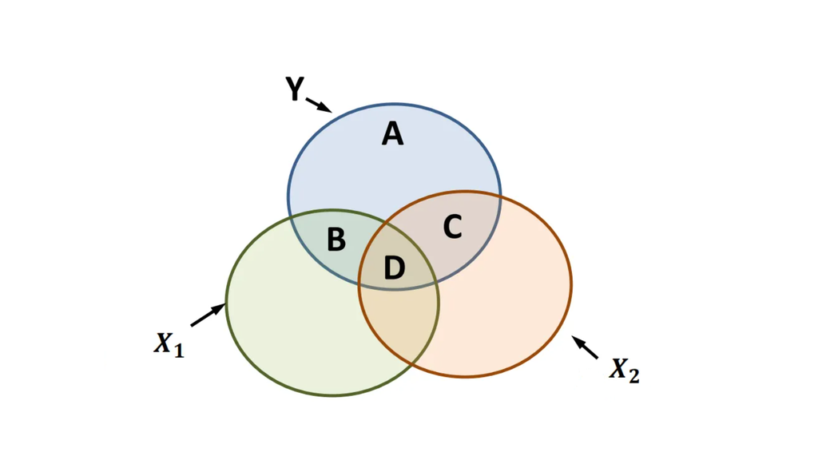

Venn

```r
ppcor::spcor(heart[,-1])
```

```
## $estimate
##                   biking   smoking heart.disease
## biking         1.0000000 0.3199876    -0.9885545
## smoking        0.8609963 1.0000000     0.9146844
## heart.disease -0.9402423 0.3233272     1.0000000
##
## $p.value
##                      biking      smoking heart.disease
## biking         0.000000e+00 2.697044e-13  0.000000e+00
## smoking       1.906168e-147 0.000000e+00 6.944391e-197
## heart.disease 9.615805e-234 1.475567e-13  0.000000e+00
##
## $statistic
##                  biking  smoking heart.disease
## biking          0.00000 7.514367    -145.78614
## smoking        37.66326 0.000000      50.35132
## heart.disease -61.43520 7.601896       0.00000
##
## $n
## [1] 498
##
## $gp
## [1] 1
##
## $method
## [1] "pearson"
```

# Sample size

**Minimum sample size**

# Multicollinearity

If a predictor can be perfectly predicted by other predictors, the correlation matrix is said to be singular, and a regression equation cannot be found.

## Variance Inflation Factor (VIF)

The degree to which a predictor can be predicted by a combination of all other predictors in the model can be measured by tolerance or its reciprocal, the Variance Inflation Factor (VIF)

$$Tolerance=1-R_c^2$$
$$VIF=\frac{1}{Tolerance}$$
A high value for tolerance means that the predictor in question is relatively independent of the other predictors (tolerance <0.1 suggest serious multicollinearity, 0.2 suggests potential multicollinearity).

```r
car::vif(fit)
```

```
##   biking  smoking
## 1.000229 1.000229
```

# Outliers

Cook distance: large values marks potential outliers.

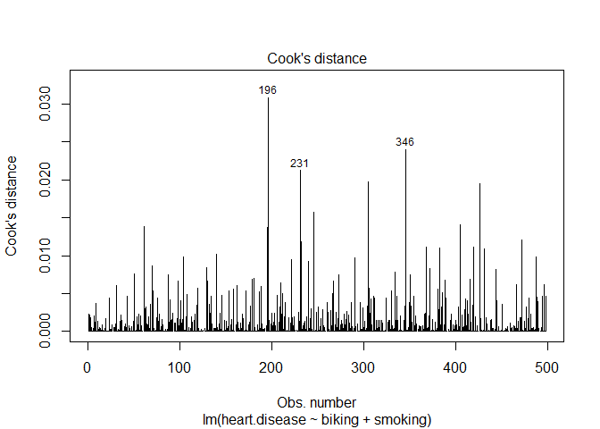

```r
plot(fit, which=4)
```

When both Cook’s distance and leverage value are large, the observation is more likely an outlier.

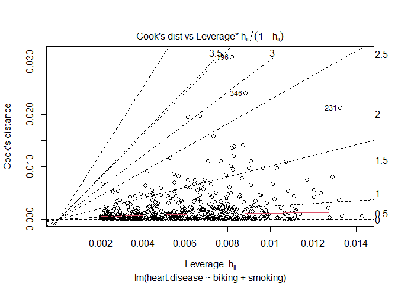

```r
plot(fit, which=6)
```

# Residuals

Residuals vs Y_hat (fitted response): ideally they should be independent.

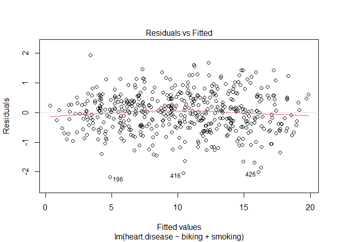

```r
plot(fit, which=1)
```

QQ plot for standardized residuals: ideally they should be following y = x, indicating a Gaussian distribution underlies it.

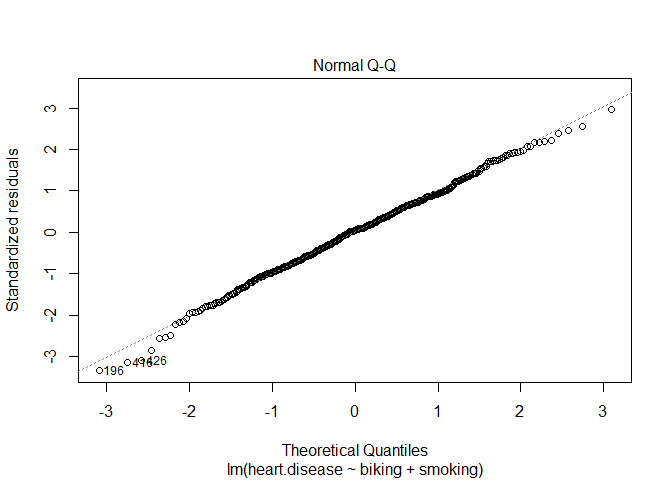

```r
plot(fit, which=2)
```

# Key information to report for MLR

- **$R_{adj}^2$**:SS% explained?

  > 75%, very good ; 50-75%, good; 25-50%, OK; <25%, insufficient
- **F test**: Significant association between IV (x) and DV (y)?

  > H0: no association …
- **B regression coefficient/slope**: The relation between DV and each IV when keeping all other IV constant?
- **standardized beta**: Which IV contributes most to DV?

  > Standardized beta weights: z-scores of IVs and DV for regression
- **t**: Significant association between each IV and DV?

## MLR in *BruceR*

```r
bruceR::model_summary(fit)
```

```
##
## Model Summary
##
## ──────────────────────────────
##              (1) heart.disease
## ──────────────────────────────
## (Intercept)   14.985 ***
##               (0.080)
## biking        -0.200 ***
##               (0.001)
## smoking        0.178 ***
##               (0.004)
## ──────────────────────────────
## R^2            0.980
## Adj. R^2       0.980
## Num. obs.    498
## ──────────────────────────────
## Note. * p < .05, ** p < .01, *** p < .001.
##
## # Check for Multicollinearity
##
## Low Correlation
##
##     Term  VIF  VIF 95% CI Increased SE Tolerance Tolerance 95% CI
##   biking 1.00 [1.00, Inf]         1.00      1.00     [0.00, 1.00]
##  smoking 1.00 [1.00, Inf]         1.00      1.00     [0.00, 1.00]
```

```r
bruceR::GLM_summary(fit)
```

```
##
## General Linear Model (OLS Regression)
##
## Model Fit:
## F(2, 495) = 11895.24, p < 1e-99 ***
## R² = 0.97962 (Adjusted R² = 0.97954)
##
## Unstandardized Coefficients:
## Outcome Variable: heart.disease
## N = 498
## ─────────────────────────────────────────────────────────────────────
##                   b    S.E.        t     p        [95% CI of b]   VIF
## ─────────────────────────────────────────────────────────────────────
## (Intercept)  14.985 (0.080)  186.988 <.001 *** [14.827, 15.142]
## biking       -0.200 (0.001) -146.525 <.001 *** [-0.203, -0.197] 1.000
## smoking       0.178 (0.004)   50.387 <.001 *** [ 0.171,  0.185] 1.000
## ─────────────────────────────────────────────────────────────────────
##
## Standardized Coefficients (β):
## Outcome Variable: heart.disease
## N = 498
## ──────────────────────────────────────────────────────────────────────────────
##               β    S.E.        t     p        [95% CI of β] r(partial) r(part)
## ──────────────────────────────────────────────────────────────────────────────
## biking   -0.940 (0.006) -146.525 <.001 *** [-0.953, -0.928]     -0.989  -0.940
## smoking   0.323 (0.006)   50.387 <.001 *** [ 0.311,  0.336]      0.915   0.323
## ──────────────────────────────────────────────────────────────────────────────
```